# Income and Renewable Heating Adoption in Switzerland

Yannik Zimmermann & Birk Diener

2026-05-21

## Motivation

Switzerland has committed to achieving net-zero greenhouse gas emissions by 2050, with the heating sector representing one of the largest remaining sources of fossil fuel consumption. Transitioning residential buildings away from oil and gas heating towards renewable alternatives such as heat pumps, solar thermal systems, and biomass is therefore a critical lever of the energy transition. However, adoption rates of renewable heating systems vary significantly across Swiss municipalities (bfs 2024). This project investigates a potential explanation for this heterogenous adoption pattern, namely whether a statistically measurable relationship exists between community-level income and the share of renewable heating systems installed.

## Project Aim

This project aims to quantify the relationship between median income at the municipality level and the share of buildings equipped with renewable heating systems across Swiss municipalities. The analysis will address two core research questions:

- Is there a statistically significant relationship between municipal-level financial capacity, measured through taxable income, and the share of residential buildings equipped with renewable heating systems across Swiss municipalities?
- To what extent is this relationship robust to structural characteristics of the building stock, namely the share of single-family houses and the age of the building stock, and to cantonal differences in subsidy programmes?

The analysis draws on the Federal Building and Dwellings Register (GWR) and ESTV municipal tax data. Given known data quality limitations in the GWR heating system entries, a systematic data recency assessment is integrated into the analysis prior to modelling. The findings will be visualised through choropleth maps and scatter plots to make spatial and socioeconomic patterns legible for a broader audience.

## Data Sources

Two datasets are used for this analysis, both openly available and joinable at the Swiss municipality level (BFS-Gemeindecode). The first is the Federal Building and Dwellings register (GWR), which records the primary heating energy, building category, and year of construction for every residential building in Switzerland. Key variables used in this analysis are the heating system type (GWAERZH1), the energy source (GENH1), the year of construction (GBAUJ), the information source of the heating entry (GWAERSCEH1), the last update date of the heating entry (GWAERDATH1), and the municipality code (GGDENR).

While the general availability of data to answer the research question is good, there is a significant challenge regarding the reliability of the heating system entries. The last comprehensive national update of this information took place as part of the Volkszählung 2000. Since then, municipal building departments are responsible for updating entries, primarily through building permit applications. As a result, data quality varies across municipalities, and heating systems installed without a building permit — such as most external air-source heat pumps — may not be recorded. We investigate this aspect further in the data preparation chapter.

The second dataset is the income and wealth statistics from the Federal Tax Administration (ESTV), which provides median taxable income per municipality at the level of natural persons. It is published annually with a lag of approximately two years.

## Approach

Fourth, findings are visualized through choropleth maps showing the spatial distribution of renewable heating adoption and median income respectively.

## Data Preparation

Before proceeding to the analysis, the GWR building data is prepared and aggregated to the municipal level. The preparation process includes filtering for residential buildings, flagging renewable heating systems, andÍ assessing the quality of the heating system entries.

Residential buildings are identified using two GWR variables. First, GKAT (building category) is restricted to codes 1020 (exclusively residential) and 1030 (residential with secondary use), excluding buildings without mostly residential use. Second, GSTAT (building status) is restricted to code 1004, retaining only buildings recorded as currently existing and excluding buildings under construction, demolished, or otherwise inactive. Together, these two filters define the analytical population of existing residential buildings on which all subsequent measures are computed.

```r
## 1. Read the GWR building data --------------------------------------------
# The file is tab-separated even though it ends in .csv. We only read the
# columns we actually use (the full file has ~50 columns and ~3.3 M rows).

buildings <- read_tsv(
  here("gwr", "gebaeude_batiment_edificio.csv"),
  col_select = c(GGDENR, GGDENAME, GDEKT,
                 GKAT, GKLAS, GSTAT, GBAUJ,
                 GWAERZH1, GENH1, GWAERSCEH1, GWAERDATH1),
  na = c("", "NA"),
  show_col_types = FALSE
)

## 2. Keep only existing residential buildings -----------------------------
# GKAT: 1020 = exclusively residential, 1030 = residential with side use
# GSTAT 1004 = the building actually exists today.

residential <- buildings %>%
  filter(GKAT %in% c(1020, 1030), GSTAT == 1004)


## 3. Flag each building --------------------------------------------------
# Renewable heating per the project brief:

residential <- residential %>%
  mutate(
    # ------------------------------------------------------------------
    # 1. Heizsystem-Kategorien — GENH1
    # ------------------------------------------------------------------
    is_no_heatsystem = GENH1 == 7500,
    is_hp_air        = GENH1 == 7501,
    is_hp_ground     = GENH1 %in% c(7510, 7511, 7512, 7513),
    is_gas           = GENH1 == 7520,
    is_oil           = GENH1 == 7530,
    is_wood          = GENH1 %in% c(7540, 7541, 7542, 7543),
    is_waste_heat    = GENH1 == 7550,
    is_electric      = GENH1 == 7560,
    is_solar         = GENH1 == 7570,
    is_district      = GENH1 %in% c(7580, 7581, 7582),
    is_other         = GENH1 %in% c(7598, 7599),

    # Aggregierte Heizsystem-Flags
    is_heatpump      = is_hp_air | is_hp_ground,
    is_renewable     = is_heatpump | is_wood | is_solar |
                       is_waste_heat | is_no_heatsystem,

    # ------------------------------------------------------------------
    # 2. Gebäudestruktur
    # ------------------------------------------------------------------
    is_efh           = GKLAS == 1110,

    # ------------------------------------------------------------------
    # 3. Gebäudealter — Flags und Faktorvariable
    # ------------------------------------------------------------------
    is_pre1945       = !is.na(GBAUJ) & GBAUJ < 1945,
    is_postwar       = !is.na(GBAUJ) & GBAUJ >= 1945 & GBAUJ < 1981,
    is_transition    = !is.na(GBAUJ) & GBAUJ >= 1981 & GBAUJ < 2001,
    is_modern        = !is.na(GBAUJ) & GBAUJ >= 2001 & GBAUJ < 2021,
    is_new           = !is.na(GBAUJ) & GBAUJ >= 2021,
    is_age_unknown   = is.na(GBAUJ),

    building_epoch   = factor(
      case_when(
        is.na(GBAUJ)   ~ "unknown",
        GBAUJ < 1945   ~ "pre1945",
        GBAUJ < 1981   ~ "postwar",
        GBAUJ < 2001   ~ "transition",
        GBAUJ < 2021   ~ "modern",
        TRUE           ~ "new"
      ),
      levels = c("pre1945", "postwar", "transition", "modern", "new", "unknown")
    ),

    # ------------------------------------------------------------------
    # 4. Datenqualität
    # ------------------------------------------------------------------
    is_lowqual       = GWAERSCEH1 == 860 | is.na(GWAERDATH1)
  )

residential <- residential %>%
  mutate(across(starts_with("is_"), ~ coalesce(.x, FALSE)))

## 5. Aggregate to the municipality ---------------------------------------
# Renewable share is defined over buildings with a heating entry, so the
# denominator is sum(!is.na(GWAERZH1)), not n().

muni <- residential %>%
  group_by(bfs_id = GGDENR, municipality = GGDENAME, canton = GDEKT) %>%
  summarise(
    # ------------------------------------------------------------------
    # 1. Grundzahlen
    # ------------------------------------------------------------------
    n_buildings          = n(),
    n_missing_heating    = sum(is.na(GENH1)),

    # ------------------------------------------------------------------
    # 2. Heizsystem-Anteile (Nenner: alle Gebäude)
    # ------------------------------------------------------------------
    share_renewable      = sum(is_renewable)  / n(),
    share_heatpump       = sum(is_heatpump)   / n(),
    share_hp_air         = sum(is_hp_air)     / n(),
    share_hp_ground      = sum(is_hp_ground)  / n(),
    share_solar          = sum(is_solar)      / n(),
    share_wood           = sum(is_wood)       / n(),
    share_waste_heat     = sum(is_waste_heat) / n(),
    share_oil            = sum(is_oil)        / n(),
    share_gas            = sum(is_gas)        / n(),
    share_electric       = sum(is_electric)   / n(),
    share_district       = sum(is_district)   / n(),
    share_other          = sum(is_other)      / n(),

    # ------------------------------------------------------------------
    # 3. Gebäudestruktur (Nenner: alle Gebäude)
    # ------------------------------------------------------------------
    share_efh            = sum(is_efh)        / n(),

    # ------------------------------------------------------------------
    # 4. Gebäudealter (Nenner: alle Gebäude)
    # ------------------------------------------------------------------
    share_pre1945        = sum(is_pre1945)    / n(),
    share_postwar        = sum(is_postwar)    / n(),
    share_transition     = sum(is_transition) / n(),
    share_modern         = sum(is_modern)     / n(),
    share_new            = sum(is_new)        / n(),
    share_age_unknown    = sum(is_age_unknown) / n(),

    # ------------------------------------------------------------------
    # 5. Datenqualität (Nenner: alle Gebäude)
    # ------------------------------------------------------------------
    share_lowqual        = sum(is_lowqual)    / n(),

    .groups = "drop"
  )
```

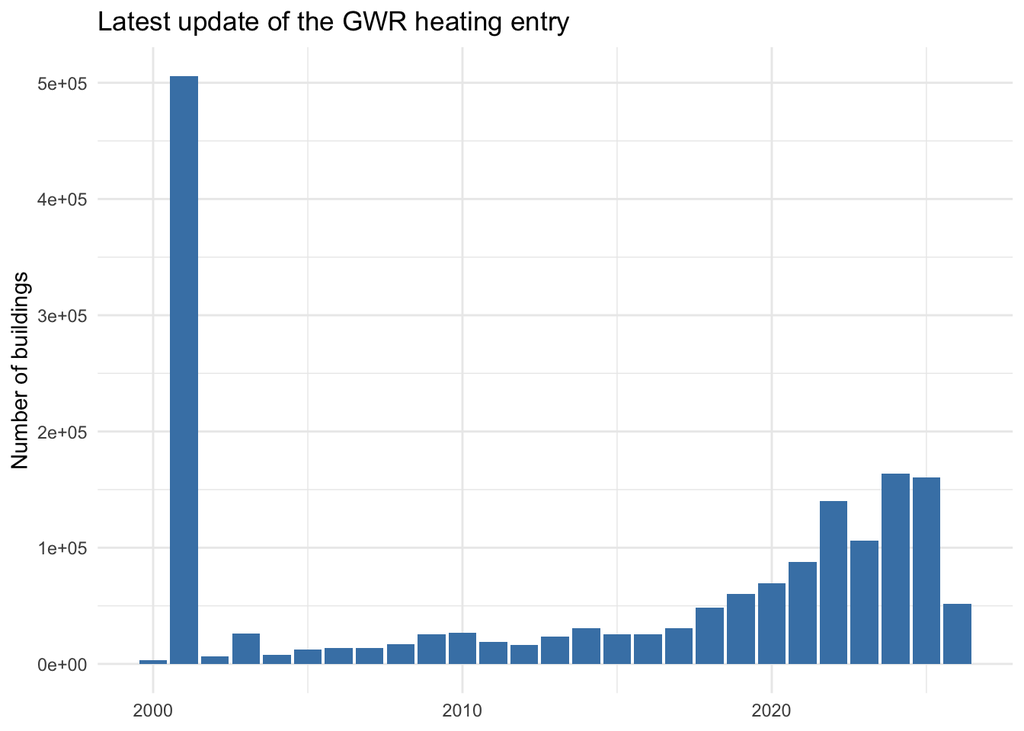

```r
## 4. Quick data-quality check --------------------------------------------
# When was the heating entry last updated? The brief notes this is a problem,
# many entries still go back to the 2000 census.

residential %>%
  mutate(year = as.integer(substr(GWAERDATH1, 1, 4))) %>%
  filter(!is.na(year), year >= 1990) %>%
  ggplot(aes(year)) +
  geom_bar(fill = "steelblue") +
  labs(title = "Latest update of the GWR heating entry",
       x = NULL, y = "Number of buildings") +
  theme_minimal()
```

Figure 1: Distribution of GWR heating entry update years for residential buildings in Switzerland

*Note: The figure shows the number of residential buildings by the year of their most recent heating system entry update (GWAERDATH1). Buildings with no recorded update date (n = 1,083,361) are excluded from the plot. The spike in 2001 reflects entries sourced from the Volkszählung 2000 (GWAERSCEH1 = 860), which represent the last comprehensive national update of heating system data. The subsequent increase from 2019 onwards reflects growing administrative activity following the 2017 revision of the GWR ordinance, which made heating data recording mandatory for new building permits.*

```r
estv_file <- here("estv", "statistik-dbst-np-kennzahlen-mit-2022.xlsx")

income <- read_excel(
  estv_file,
  sheet = "Gemeinden - Communes",
  na    = c("", "NA", "-")
) %>%
  select(bfs_id = 3, median_income = median_steink) %>%
  filter(!is.na(bfs_id))

muni_joined <- muni %>%
  left_join(income, by = "bfs_id")

muni_analysis <- muni_joined %>%
  filter(!is.na(median_income))
```

Of the 2,110 municipalities in the analytical sample, 12 could not be matched to ESTV income data, most likely due to municipal mergers where GWR and ESTV use different reference dates for municipality codes. These municipalities are excluded from the regression analysis, leaving a final sample of 2,098 municipalities.

```r
## STATPOP — Einwohnerzahl pro Gemeinde
statpop <- read_delim(
  here("gwr", "STATPOP2024_GMDE.csv"),
  delim = ";",
  show_col_types = FALSE
) %>%
  select(bfs_id = GMDE, pop_total = BBTOT)

## Raumgliederungen — Gemeindetypologie
raumgliederung <- read_excel(
  here("gwr", "Raumgliederungen.xlsx"),
  skip = 2,
  col_names = c("bfs_id", "muni_name", "canton_id", "canton",
                "district_id", "district", "typology_3",
                "typology_9", "typology_25")
) %>%
  filter(!is.na(bfs_id)) %>%
  select(bfs_id, typology_3, typology_9, typology_25) %>%
  mutate(
    bfs_id     = as.numeric(bfs_id),
    typology_3 = as.integer(typology_3),
    typology_9 = as.integer(typology_9),
    typology_25 = as.integer(typology_25)
  )

muni_analysis <- muni_analysis %>%
  left_join(statpop,       by = "bfs_id") %>%
  left_join(raumgliederung, by = "bfs_id") %>%
  mutate(log_pop = log(pop_total))
```

## Analysis

### Univariate Statistics

```r
## ── EDA ──────────────────────────────────────────────────────────────────────

## 1. Univariate Statistiken ---------------------------------------------------
muni_analysis %>%
  select(share_renewable, median_income, share_efh,
         share_lowqual, log_pop) %>%
  summary()
```

```
##  share_renewable  median_income      share_efh      share_lowqual
##  Min.   :0.0136   Min.   :  6900   Min.   :0.1153   Min.   :0.0000
##  1st Qu.:0.1621   1st Qu.: 54800   1st Qu.:0.6069   1st Qu.:0.1830
##  Median :0.2548   Median : 59700   Median :0.7002   Median :0.3181
##  Mean   :0.2837   Mean   : 61003   Mean   :0.6794   Mean   :0.3431
##  3rd Qu.:0.3745   3rd Qu.: 65688   3rd Qu.:0.7686   3rd Qu.:0.5101
##  Max.   :0.9355   Max.   :115300   Max.   :0.9750   Max.   :0.9135
##     log_pop
##  Min.   : 3.466
##  1st Qu.: 6.678
##  Median : 7.457
##  Mean   : 7.499
##  3rd Qu.: 8.354
##  Max.   :12.987
```

The dependent variable share_renewable is right-skewed (Median 25.5%, Mean 28.4%, IQR 16.2–37.5%). The majority of municipalities fall between a 15% and 35% share of renewable heating, while a long right-hand tail extends up to 93.6%. The distribution is not skewed enough to warrant a log transformation but should be treated as a proportion during model interpretation.

Median income (median_income) is approximately symmetrically distributed (Median 59,700 CHF, IQR 54,800–65,688 CHF) with a slight right-hand tail reaching up to 115,300 CHF – driven by high-income, tax-advantaged municipalities, primarily in Zug and Schwyz. A log transformation is plausible for the regression here, as the distribution at the lower end (from approx. 30,000 CHF downwards) exhibits stronger left-skewness. The minimum of 6,900 CHF is likely due to isolated micro-municipalities with unreliable FTA (ESTV) entries.

The share of single-family houses (share_efh) varies considerably across municipalities (Median 70.0%, IQR 60.7–76.9%, Min 11.5%, Max 97.5%). Urban centres such as Zurich or Geneva fall at the lower end of the distribution, where multi-family buildings dominate the housing stock, while small rural municipalities consist almost entirely of detached housing. The positive correlation with share_renewable (r = 0.15) is in the expected direction: municipalities with a higher share of single-family houses tend to show higher renewable heating adoption, consistent with heat pumps and wood heating being predominantly installed in detached buildings.

The share of low-quality GWR heating entries (share_lowqual, Median 31.8%, IQR 18.3–51.0%) confirms the challenge outlined in the data description: one-third of the entries are outdated or undated. The wide dispersion indicates that using this share as a control variable is sensible, as it absorbs measurement noise at the municipal level.

### Correlation Matrix

```r
## 2. Korrelationsmatrix -------------------------------------------------------
cor_matrix <- muni_analysis %>%
  select(share_renewable, median_income, share_efh,
         share_pre1945, share_lowqual, log_pop) %>%
  cor(use = "complete.obs") %>%
  round(2)

cor_matrix
```

```
##                 share_renewable median_income share_efh share_pre1945
## share_renewable            1.00         -0.36      0.15         -0.04
## median_income             -0.36          1.00      0.19          0.07
## share_efh                  0.15          0.19      1.00         -0.05
## share_pre1945             -0.04          0.07     -0.05          1.00
## share_lowqual             -0.02         -0.13      0.06          0.06
## log_pop                   -0.39          0.13     -0.31         -0.15
##                 share_lowqual log_pop
## share_renewable         -0.02   -0.39
## median_income           -0.13    0.13
## share_efh                0.06   -0.31
## share_pre1945            0.06   -0.15
## share_lowqual            1.00   -0.15
## log_pop                 -0.15    1.00
```

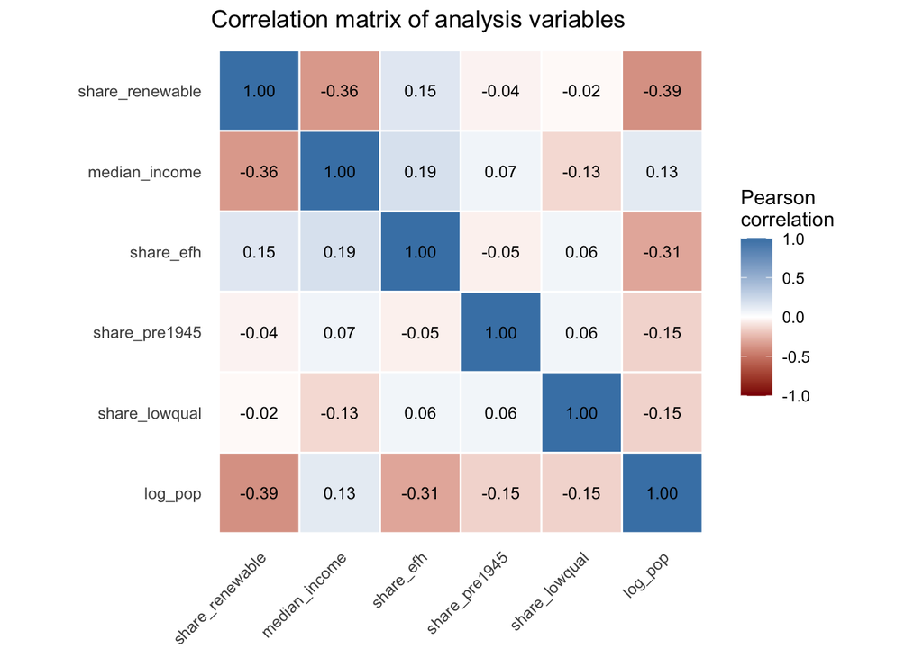

```r
## Correlation plot ------------------------------------------------------------
cor_matrix %>%
  as.data.frame() %>%
  rownames_to_column("var1") %>%
  pivot_longer(-var1, names_to = "var2", values_to = "corr") %>%
  mutate(
    var1 = factor(var1, levels = rownames(cor_matrix)),
    var2 = factor(var2, levels = rev(rownames(cor_matrix)))
  ) %>%
  ggplot(aes(var1, var2, fill = corr)) +
  geom_tile(colour = "white", linewidth = 0.5) +
  geom_text(aes(label = sprintf("%.2f", corr)), size = 3.2) +
  scale_fill_gradient2(
    low      = "darkred",
    mid      = "white",
    high     = "steelblue",
    midpoint = 0,
    limits   = c(-1, 1),
    name     = "Pearson\ncorrelation"
  ) +
  labs(
    title = "Correlation matrix of analysis variables",
    x     = NULL,
    y     = NULL
  ) +
  coord_fixed() +
  theme_minimal() +
  theme(
    axis.text.x      = element_text(angle = 45, hjust = 1),
    panel.grid.major = element_blank(),
    panel.grid.minor = element_blank()
  )
```

Figure 2: Pearson correlation matrix of the main analysis variables across all 2,098 municipalities in the analytical sample.

The most striking finding in the correlation matrix is the negative correlation between median income and the share of renewable heating (r = –0.36). This contradicts the intuitive expectation that higher purchasing power facilitates the adoption of renewable heating systems. This effect is explained by the urban concentration of high-income municipalities: due to structural factors, urban municipalities have lower renewable shares—gas heating and district heating (excluded here) dominate—but above-average incomes.

The share of single-family houses (share_efh) is positively correlated with share_renewable (r = 0.15) and median_income (r = 0.19), and negatively correlated with log_pop (r = –0.31), confirming that larger, denser municipalities have fewer single-family houses and lower renewable shares. This pattern suggests that share_efh partially mediates the relationship between urbanity and renewable adoption, and its inclusion in the regression will help disentangle the income effect from building stock composition.

Also relevant is the negative correlation between municipality size (log_pop) and the renewable share (r = –0.39). Larger municipalities rely more heavily on fossil fuels. Since income and population size are weakly positively correlated (r = 0.13), potential multicollinearity exists, though it is non-critical at this level.

share_pre1945 shows virtually no correlation with share_renewable (r = –0.04), which is surprising at first glance, as older buildings typically have lower renovation rates. A possible explanation: in municipalities with a high share of old buildings, the GWR data entries are also older, potentially biasing the measured renewable rate upward (outdated entries may fail to classify electric heating as fossil-fuel-based, for example). The low correlation of share_lowqual with all other variables (max. |r| = 0.15) suggests that data quality issues are not systematically related to income, supporting its use as a control variable.

### Distribution of share_renewable (Histogram)

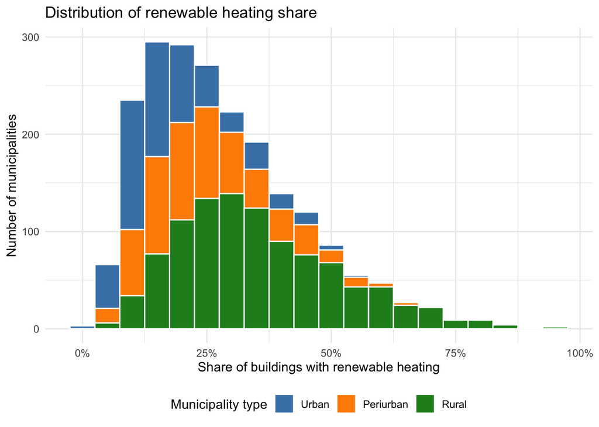

```r
## 3. Plot 1 — Verteilung share_renewable -------------------------------------
# Konsistente Typologie-Labels (gleiche Reihenfolge und Farben wie bei den
# folgenden Scatter- und Boxplots)
typology_labels <- c("1" = "Urban", "2" = "Periurban", "3" = "Rural")

p1 <- muni_analysis %>%
  mutate(typology_3 = factor(typology_3, labels = typology_labels)) %>%
  ggplot(aes(share_renewable, fill = typology_3)) +
  geom_histogram(binwidth = 0.05, colour = "white", position = "stack") +
  scale_x_continuous(labels = scales::percent_format()) +
  scale_fill_manual(values = c("Urban"     = "steelblue",
                               "Periurban" = "darkorange",
                               "Rural"     = "forestgreen")) +
  labs(
    title = "Distribution of renewable heating share",
    x     = "Share of buildings with renewable heating",
    y     = "Number of municipalities",
    fill  = "Municipality type"
  ) +
  theme_minimal() +
  theme(legend.position = "bottom")

p1
```

Figure 3: Distribution of the renewable heating share across Swiss municipalities.

The distribution shows a clear peak at 15–30%, with the highest concentration between 10% and 35%. Only a few municipalities exceed 50%, and the tail beyond 75% likely represents small alpine municipalities with a high share of wood heating. The histogram supports using the untransformed variable as the outcome, given that the skewness is moderate. A beta regression or an arcsine transformation would be indicated if there were a stronger concentration at the boundaries (near 0 or 1), which is not the case here.

### Distribution of median_income (Histogram)

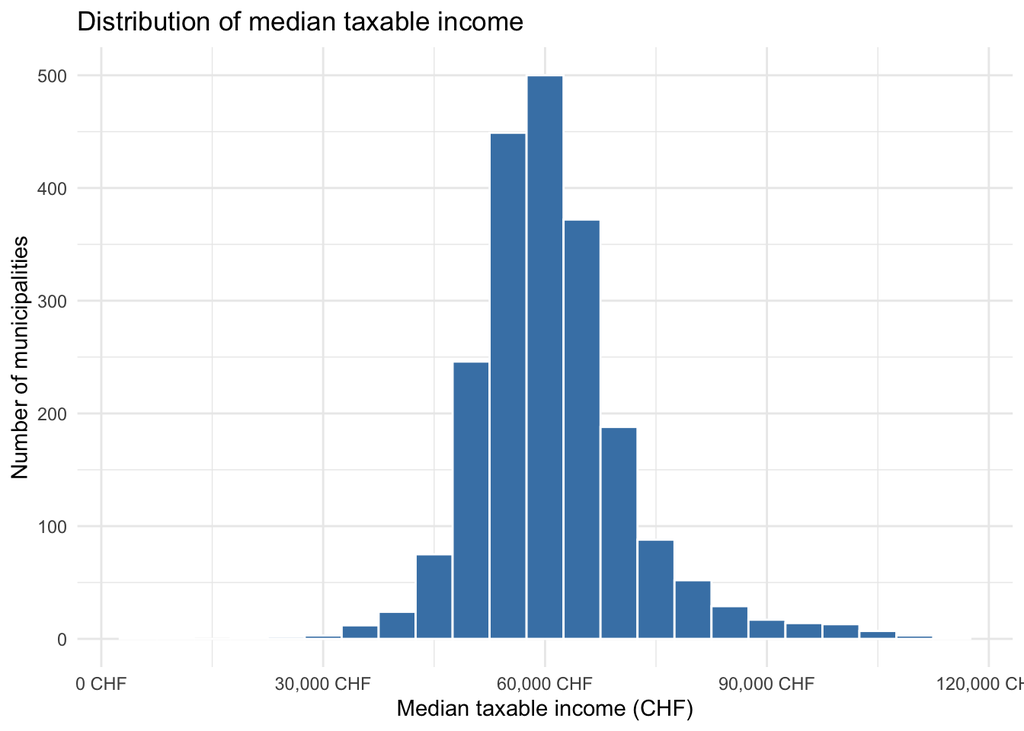

```r
## 4. Plot 2 — Verteilung median_income ----------------------------------------
p2 <- muni_analysis %>%
  ggplot(aes(median_income)) +
  geom_histogram(binwidth = 5000, fill = "steelblue", colour = "white") +
  scale_x_continuous(labels = scales::comma_format(suffix = " CHF")) +
  labs(
    title = "Distribution of median taxable income",
    x     = "Median taxable income (CHF)",
    y     = "Number of municipalities"
  ) +
  theme_minimal()

p2
```

Figure 4: Distribution of median taxable income across Swiss municipalities (ESTV 2022).

The income distribution is unimodal and approximately normally distributed in its core range (40,000–80,000 CHF), with a right-hand tail caused by low-tax municipalities. The sharp drop-off below 30,000 CHF reflects the Swiss price level; outliers below this threshold require methodological verification. For the regression, a robustness check using log-transformed income is recommended: the relationship between purchasing power and adoption behavior is plausibly non-linear (each additional franc has a stronger impact at lower income levels than at higher ones).

### Scatterplot: Income vs. Renewable Share by Municipality Type

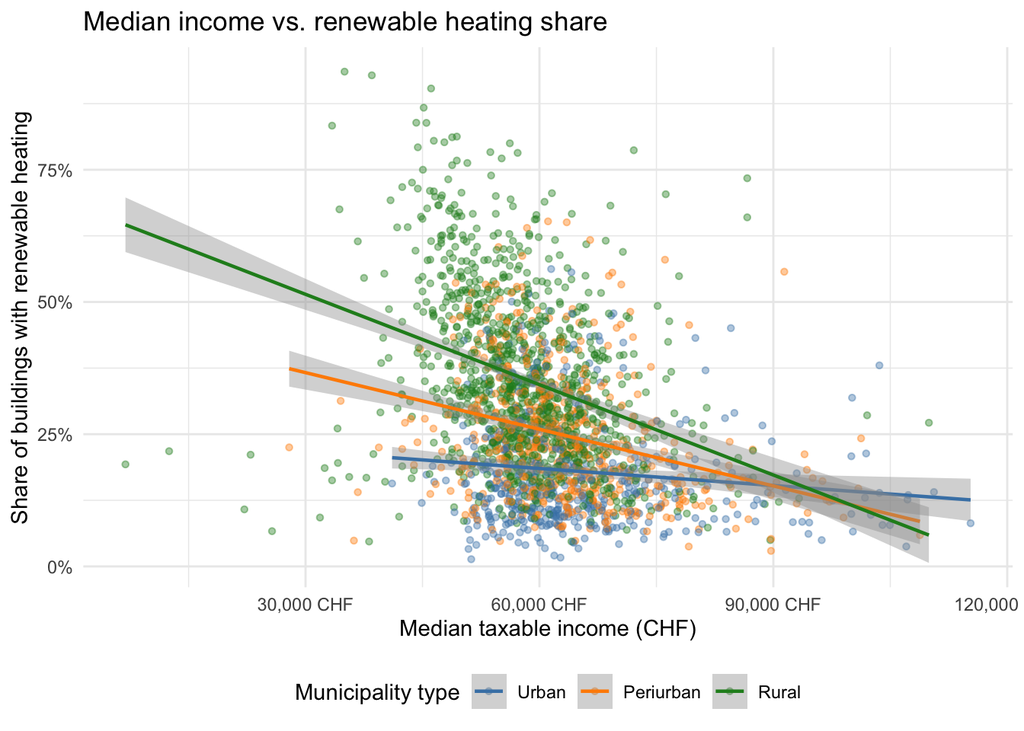

```r
## 5. Plot 3 — Scatterplot median_income vs. share_renewable -------------------
typology_labels <- c("1" = "Urban", "2" = "Periurban", "3" = "Rural")

p3 <- muni_analysis %>%
  mutate(typology_3 = factor(typology_3, labels = typology_labels)) %>%
  ggplot(aes(median_income, share_renewable, colour = typology_3)) +
  geom_point(alpha = 0.4, size = 1.2) +
  geom_smooth(method = "lm", se = TRUE, linewidth = 0.8) +
  scale_x_continuous(labels = scales::comma_format(suffix = " CHF")) +
  scale_y_continuous(labels = scales::percent_format()) +
  scale_colour_manual(values = c("steelblue", "darkorange", "forestgreen")) +
  labs(
    title   = "Median income vs. renewable heating share",
    x       = "Median taxable income (CHF)",
    y       = "Share of buildings with renewable heating",
    colour  = "Municipality type"
  ) +
  theme_minimal() +
  theme(legend.position = "bottom")

p3
```

Figure 5: Scatterplot of median taxable income against the renewable heating share, with OLS regression lines fitted separately for urban, peri-urban, and rural municipalities.

The scatterplot yields the central finding of the EDA. Three patterns stand out:

```
Direction: The relationship is negative across all three municipality types—as income increases, the share of renewable heating decreases. The OLS regression lines consistently display a negative slope, which is steepest for rural municipalities (green).

Level Differences: At any given income level, rural municipalities (green) have a significantly higher renewable share than peri-urban (orange) and urban municipalities (blue). At around 55,000–65,000 CHF, rural municipalities sit approximately 15–25 percentage points above the urban level. This reflects a structural composition difference: wood heating and heat pumps in detached single-family homes dominate the rural building stock.

Dispersion: The very wide dispersion—particularly in rural areas—shows that income alone explains only a fraction of the variance. This is consistent with r = –0.36. For the regression, this implies that further explanatory power must be derived from control variables and canton fixed effects.
```

Interpretation of the negative direction: The surprising negative sign is highly likely a composition effect: high-income municipalities are disproportionately urban (higher log_pop, more gas/district heating), while lower-income municipalities are disproportionately rural (more wood, heat pumps in single-family homes). Whether income exerts a true causal effect on heating adoption—independent of urbanity and building structure—will be revealed by the regression with controls.

### Boxplot: Renewables by Municipality Type

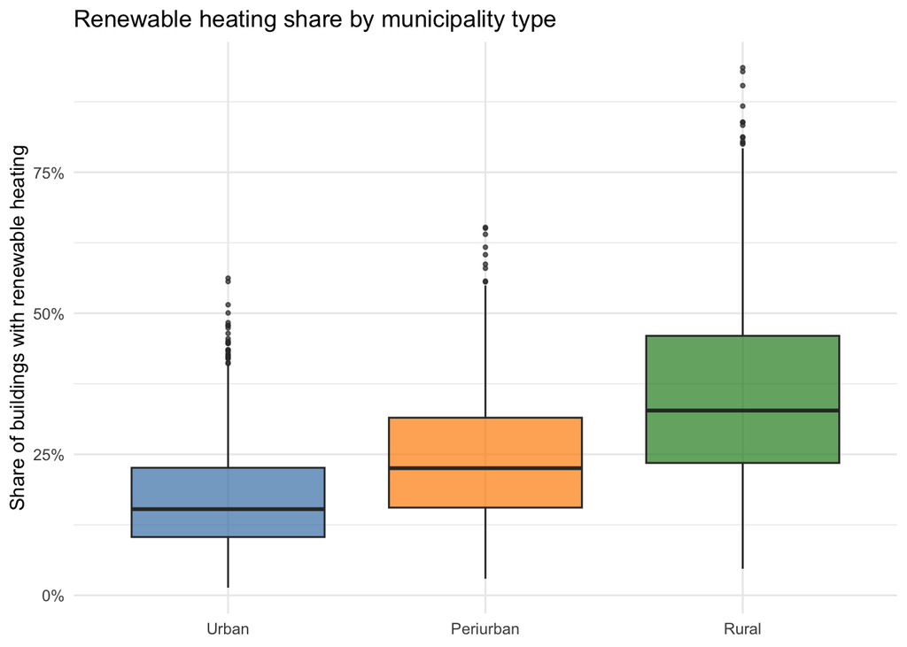

```r
## 6. Plot 4 — Boxplot share_renewable nach typology_3 ------------------------
p4 <- muni_analysis %>%
  mutate(typology_3 = factor(typology_3, labels = typology_labels)) %>%
  ggplot(aes(typology_3, share_renewable, fill = typology_3)) +
  geom_boxplot(alpha = 0.7, outlier.size = 0.8) +
  scale_y_continuous(labels = scales::percent_format()) +
  scale_fill_manual(values = c("steelblue", "darkorange", "forestgreen")) +
  labs(
    title = "Renewable heating share by municipality type",
    x     = NULL,
    y     = "Share of buildings with renewable heating"
  ) +
  theme_minimal() +
  theme(legend.position = "none")

p4
```

Figure 6: Renewable heating share by municipality type (urban, peri-urban, rural).

The boxplot confirms the typological gradient: rural municipalities (median ~33%) > peri-urban (median ~23%) > urban (median ~15%). The IQR for rural municipalities (approx. 25–47%) is considerably wider than that of urban ones (~10–25%), indicating greater heterogeneity in rural areas—likely due to cantonal differences in subsidy regimes and local fuel availability (wood vs. heat pump potential).

Upper outliers are present across all typologies; for rural municipalities, they extend beyond 90%—representing individual alpine communities with historically established shares of wood heating. Urban outliers above 50% are rare and warrant an individual municipality-level inspection (e.g., municipalities with local heat pump programs or erroneous GWR entries).

### Choropleth Maps: Renewable Share and Median Income

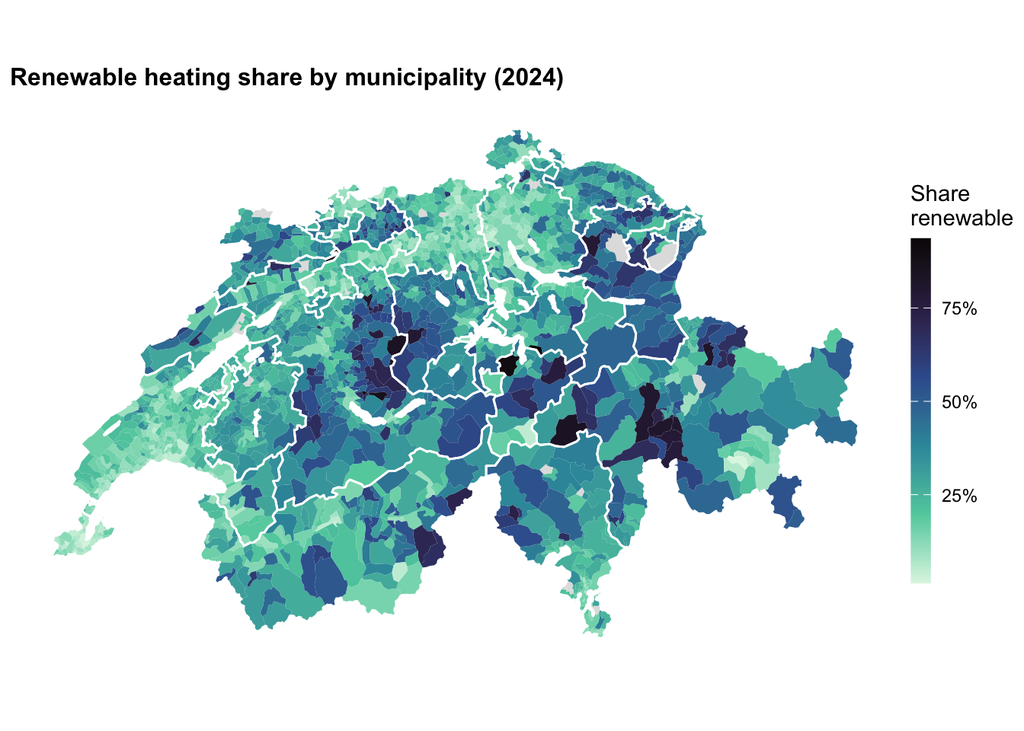

```r
# Nutze most_recent = TRUE, damit R die aktuellsten verfügbaren Karten zieht
gemeinden_sf <- bfs_get_base_maps(geom = "polg", most_recent = TRUE)
kantone_sf   <- bfs_get_base_maps(geom = "kant", most_recent = TRUE)

# Falls das klappt, kannst du direkt mit dem Join weitermachen:
map_data <- gemeinden_sf %>%
  mutate(id = as.numeric(id)) %>%
  left_join(muni_analysis, by = c("id" = "bfs_id"))

# Gemeinsames Theme für beide Karten
map_theme <- theme_void(base_size = 11) +
  theme(
    legend.position      = "right",
    legend.key.height    = unit(1.2, "cm"),
    legend.key.width     = unit(0.35, "cm"),
    plot.title           = element_text(size = 12, face = "bold", margin = margin(b = 6)),
    plot.margin          = margin(5, 5, 5, 5)
  )

# Karte 1 — Anteil erneuerbare Heizungen
p_map_renewable <- ggplot() +
  geom_sf(data = map_data,
          aes(fill = share_renewable),
          colour = NA) +
  geom_sf(data = kantone_sf,
          fill = NA, colour = "white", linewidth = 0.5) +
  scale_fill_viridis_c(
    option   = "mako",
    direction = -1,
    labels   = scales::percent_format(accuracy = 1),
    na.value = "grey88",
    name     = "Share\nrenewable"
  ) +
  labs(title = "Renewable heating share by municipality (2024)") +
  map_theme

# Karte 2 — Medianeinkommen
p_map_income <- ggplot() +
  geom_sf(data = map_data,
          aes(fill = median_income),
          colour = NA) +
  geom_sf(data = kantone_sf,
          fill = NA, colour = "white", linewidth = 0.5) +
  scale_fill_viridis_c(
    option   = "rocket",
    direction = -1,
    labels   = scales::comma_format(suffix = " k", scale = 1/1000),
    na.value = "grey88",
    name     = "Median\nincome\n(CHF)"
  ) +
  labs(title = "Median taxable income by municipality (ESTV 2022)") +
  map_theme

p_map_renewable
```

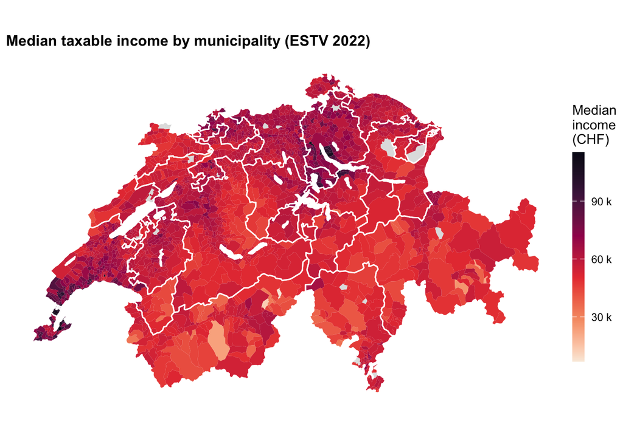

```r
p_map_income
```

Figure 7: Choropleth map of the renewable heating share by municipality across Switzerland (GWR, 2024).

Figure 8: Choropleth map of median taxable income by municipality across Switzerland (ESTV 2022).

The income map (Figure 8) shows a complementary but inverse pattern. The highest median incomes — in dark purple — are concentrated in the greater Zurich area, the canton of Zug, and the lakeside municipalities of Geneva and Vaud. These high-income clusters correspond spatially to areas of moderate to low renewable heating adoption in the first map, providing a direct visual confirmation of the negative income–renewables correlation identified in the regression. Conversely, lower-income municipalities in Valais, Ticino, and rural peripheral regions tend to appear in warmer orange tones in the income map, while displaying comparatively higher renewable shares in the first map, consistent with the wood heating patterns of lower-income rural areas.

Juxtaposing both maps makes the composition effect discussed in the regression analysis spatially legible: the negative association between income and renewable heating is not driven by a uniform within-canton pattern, but largely by the structural contrast between high-income urban and peri-urban agglomerations on the one hand and lower-income rural municipalities on the other. The substantial cantonal variation visible in both maps — particularly the sharp contrast between neighbouring cantons along the Mittelland — underscores why cantonal fixed effects absorb a large share of the explained variance in M4.

### Dominant Heating System Map

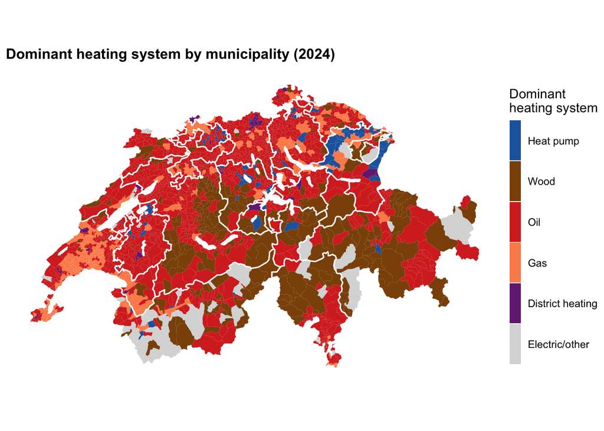

```r
# Sauberer Join — typology_3 und dominant_heating direkt aus muni_analysis
map_data_plot <- gemeinden_sf %>%
  mutate(id = as.numeric(id)) %>%
  left_join(
    muni_analysis %>%
      select(bfs_id, share_heatpump, share_oil, share_gas,
             share_wood, share_electric, share_district, typology_3),
    by = c("id" = "bfs_id")
  ) %>%
  mutate(
    dominant_heating = case_when(
      share_heatpump >= share_oil &
        share_heatpump >= share_gas &
        share_heatpump >= share_wood &
        share_heatpump >= share_electric &
        share_heatpump >= share_district   ~ "Heat pump",
      share_oil >= share_gas &
        share_oil >= share_wood &
        share_oil >= share_electric &
        share_oil >= share_district        ~ "Oil",
      share_gas >= share_wood &
        share_gas >= share_electric &
        share_gas >= share_district        ~ "Gas",
      share_wood >= share_electric &
        share_wood >= share_district       ~ "Wood",
      share_district >= share_electric     ~ "District heating",
      TRUE                                 ~ "Electric/other"
    ),
    dominant_heating = factor(dominant_heating, levels = c(
      "Heat pump", "Wood", "Oil", "Gas", "District heating", "Electric/other"
    )),
    typology_label = case_when(
      typology_3 == 1 ~ "Urban",
      typology_3 == 2 ~ "Peri-urban",
      typology_3 == 3 ~ "Rural",
      TRUE            ~ NA_character_
    )
  )

# Farbpalette Heizsystem
heating_colours <- c(
  "Heat pump"       = "#2166ac",
  "Wood"            = "#8c510a",
  "Oil"             = "#d73027",
  "Gas"             = "#fc8d59",
  "District heating" = "#762a83",
  "Electric/other"  = "#d9d9d9"
)

# Farbpalette Typologie
typology_colours <- c(
  "Urban"      = "#2166ac",
  "Peri-urban" = "#fc8d59",
  "Rural"      = "#4dac26"
)

# Karte 1 — Dominantes Heizsystem
p_map_dominant <- ggplot() +
  geom_sf(data = map_data_plot %>% filter(!is.na(dominant_heating)),
          aes(fill = dominant_heating),
          colour = NA) +
  geom_sf(data = kantone_sf,
          fill = NA, colour = "white", linewidth = 0.5) +
  scale_fill_manual(values = heating_colours, name = "Dominant\nheating system") +
  labs(title = "Dominant heating system by municipality (2024)") +
  map_theme

# Karte 2 — Gemeindetyp
p_map_typology <- ggplot() +
  geom_sf(data = map_data_plot %>% filter(!is.na(typology_label)),
          aes(fill = typology_label),
          colour = NA) +
  geom_sf(data = kantone_sf,
          fill = NA, colour = "white", linewidth = 0.5) +
  scale_fill_manual(values = typology_colours, name = "Municipality\ntype") +
  labs(title = "Municipality type (BFS typology)") +
  map_theme

p_map_dominant
```

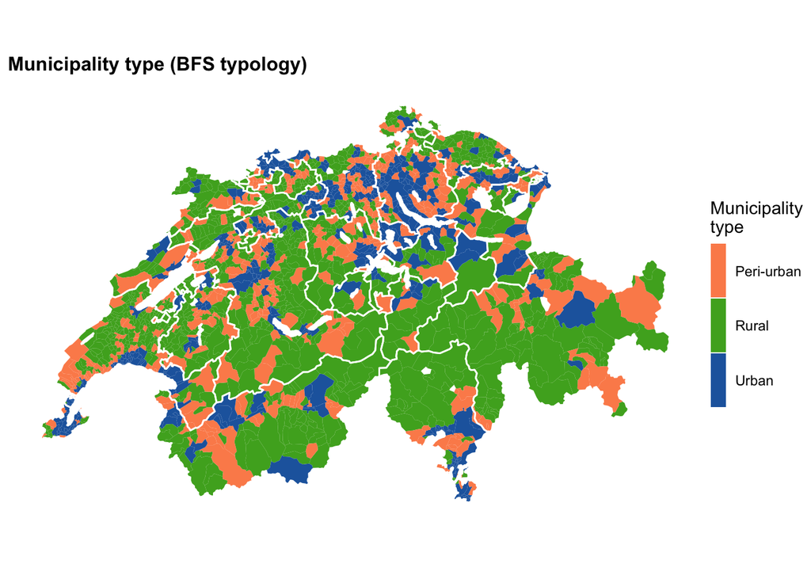

```r
p_map_typology
```

Figure 9: Dominant heating system per municipality across Switzerland (GWR, 2024).

Figure 10: Municipality type (BFS three-class typology: urban, peri-urban, rural) across Switzerland.

The municipality type map confirms the spatial pattern described in the EDA: urban municipalities are clustered along the Mittelland axis from Geneva through Zurich to St. Gallen, with additional clusters around Bern, Basel, and Lucerne. Peri-urban municipalities form a ring around these urban cores, while rural municipalities dominate the alpine regions, the Jura, and peripheral areas of eastern Switzerland. Comparing both maps, the overlap between oil-dominated municipalities and rural typology is striking — many rural areas outside the alpine wood-heating belt rely almost exclusively on oil, which has important implications for the energy transition: these municipalities combine the structural challenges of dispersed single-family housing with fossil fuel dependency, yet lack the urban infrastructure for gas or district heating alternatives.

### Regression Results

```r
# M1: Baseline
m1 <- lm(share_renewable ~ median_income + share_lowqual,
         data = muni_analysis)

# M2: + Gebäudestruktur
m2 <- lm(share_renewable ~ median_income + share_lowqual +
           share_efh + share_pre1945,
         data = muni_analysis)

# M3: + Soziodemografie
m3 <- lm(share_renewable ~ median_income + share_lowqual +
           share_efh + share_pre1945 +
           factor(typology_3) + log_pop,
         data = muni_analysis)

# M4: + Kantons-Fixed-Effects (via fixest für robuste SEs)
m4 <- feols(share_renewable ~ median_income + share_lowqual +
              share_efh + share_pre1945 +
              factor(typology_3) + log_pop | canton,
            data = muni_analysis,
            vcov = "hetero")

# Regressionstabelle
modelsummary(
  list("M1 Baseline" = m1,
       "M2 Building stock" = m2,
       "M3 Sociodem." = m3,
       "M4 Canton FE" = m4),
  coef_map = c(
    "median_income"      = "Median income (CHF)",
    "share_lowqual"      = "Share low-quality entries",
    "share_efh"          = "Share single-family houses",
    "share_pre1945"      = "Share pre-1945 buildings",
    "factor(typology_3)2" = "Peri-urban (ref: urban)",
    "factor(typology_3)3" = "Rural (ref: urban)",
    "log_pop"            = "Log population"
  ),
  stars = c("*" = 0.05, "**" = 0.01, "***" = 0.001),
  gof_map = c("nobs", "r.squared", "adj.r.squared"),
  fmt = fmt_significant(2),
  notes = "Heteroskedasticity-robust standard errors in M4.
           OLS with default SEs in M1–M3."
)
```

|  | M1 Baseline | M2 Building stock | M3 Sociodem. | M4 Canton FE |
| --- | --- | --- | --- | --- |
| Median income (CHF) | -5.4e-06*** | -6.1e-06*** | -4.2e-06*** | -1.8e-06*** |
|  | (3.0e-07) | (3.0e-07) | (2.9e-07) | (3.6e-07) |
| Share low-quality entries | -0.054*** | -0.070*** | -0.105*** | -0.048 |
|  | (0.016) | (0.016) | (0.015) | (0.032) |
| Share single-family houses |  | 0.295*** | 0.128*** | 0.181*** |
|  |  | (0.026) | (0.025) | (0.029) |
| Share pre-1945 buildings |  | 0.0097 | -0.072*** | 0.100*** |
|  |  | (0.0202) | (0.019) | (0.027) |
| Peri-urban (ref: urban) |  |  | 0.0415*** | 0.0197** |
|  |  |  | (0.0085) | (0.0061) |
| Rural (ref: urban) |  |  | 0.1111*** | 0.0744*** |
|  |  |  | (0.0097) | (0.0078) |
| Log population |  |  | -0.0196*** | -0.0332*** |
|  |  |  | (0.0031) | (0.0033) |
| Num.Obs. | 2098 | 2098 | 2098 | 2098 |
| R2 | 0.133 | 0.185 | 0.323 | 0.577 |
| R2 Adj. | 0.132 | 0.184 | 0.321 | 0.570 |

* p < 0.05, ** p < 0.01, *** p < 0.001  
Heteroskedasticity-robust standard errors in M4. OLS with default SEs in M1–M3.

Across all four model specifications, the income coefficient is negative and statistically significant at the 0.1% level, confirming the negative association observed in the EDA. The magnitude and interpretation of the effect evolves substantially as controls are added.

In the baseline model (M1), a 10,000 CHF increase in median municipal income is associated with a 5.4 percentage point reduction in the renewable heating share. Adding building stock controls in M2 slightly increases the magnitude to 6.1 percentage points. The direction of this change reflects a suppressor effect: share_efh is positively correlated with both income and renewable adoption, so controlling for it reveals a stronger direct income effect. The share of single-family houses itself is strongly positive (0.295, p < 0.001), confirming that municipalities with more detached housing have substantially higher renewable shares.

In M3, the income coefficient attenuates to –4.2 percentage points per 10,000 CHF after adding municipality type and log population. This attenuation confirms the composition hypothesis from the EDA: a substantial part of the raw negative income correlation was driven by the urban-rural gradient rather than income per se. The typology dummies show a large structural gradient—rural municipalities have an 11.1 percentage point higher renewable share than urban municipalities of comparable income and building stock, and peri-urban municipalities sit 4.2 percentage points higher.

The most notable finding is the jump in R² from 32.3% (M3) to 57.7% (M4) when cantonal fixed effects are added, while the income coefficient further attenuates to –1.8 percentage points per 10,000 CHF. This indicates strong cantonal heterogeneity—likely driven by differences in subsidy programmes, building regulations, and local energy infrastructure—that was previously confounded with the income measure. Within cantons, the income effect remains negative and significant, but is considerably smaller than the raw association suggests.

Two further findings deserve attention. First, share_pre1945 changes sign between M3 (–0.072) and M4 (+0.100): without canton fixed effects, municipalities with older building stocks tend to have fewer renewables; within cantons, the relationship reverses. This likely reflects that certain cantons combine old rural building stock with high wood heating penetration. Second, share_lowqual is significantly negative in M1–M3 but becomes insignificant in M4, suggesting that the data quality differential is primarily a between-canton rather than a within-canton phenomenon.

### Coefficient Stability Plot

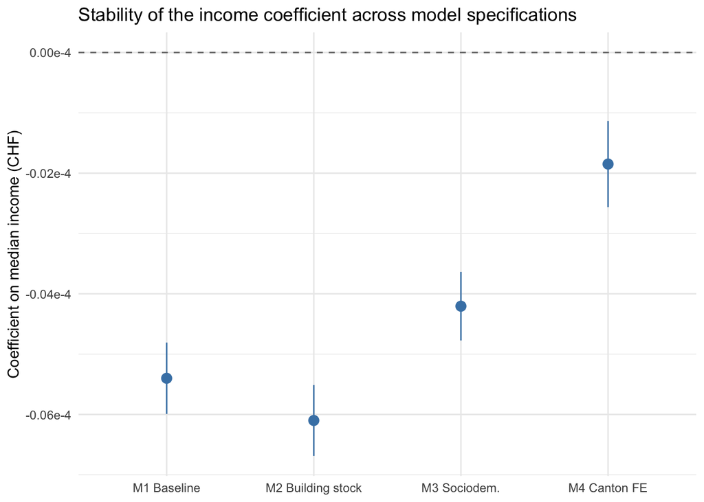

```r
# Income-Koeffizient über alle Modelle extrahieren
coef_stability <- bind_rows(
  tidy(m1, conf.int = TRUE) %>% mutate(model = "M1 Baseline"),
  tidy(m2, conf.int = TRUE) %>% mutate(model = "M2 Building stock"),
  tidy(m3, conf.int = TRUE) %>% mutate(model = "M3 Sociodem."),
  tidy(m4, conf.int = TRUE) %>% mutate(model = "M4 Canton FE")
) %>%
  filter(term == "median_income") %>%
  mutate(model = factor(model, levels = c("M1 Baseline",
                                          "M2 Building stock",
                                          "M3 Sociodem.",
                                          "M4 Canton FE")))

ggplot(coef_stability, aes(x = model, y = estimate,
                            ymin = conf.low, ymax = conf.high)) +
  geom_hline(yintercept = 0, linetype = "dashed", colour = "grey50") +
  geom_pointrange(colour = "steelblue", size = 0.6) +
  scale_y_continuous(labels = scales::label_number(scale = 1e4,
                                                    suffix = "e-4")) +
  labs(
    title = "Stability of the income coefficient across model specifications",
    x     = NULL,
    y     = "Coefficient on median income (CHF)"
  ) +
  theme_minimal()
```

Figure 11: Point estimate and 95% confidence interval of the income coefficient across the four nested regression specifications (M1–M4).

Figure 11 summarises the stability of the income coefficient across the four model specifications. The coefficient remains consistently negative across all specifications, with confidence intervals that never include zero. The point estimate shifts from –5.4e-06 in M1 to –1.8e-06 in M4, a reduction of approximately 67%, as urbanity, building structure, and cantonal heterogeneity are progressively absorbed by the controls. The widening confidence interval in M4 reflects the reduced within-canton variation available for identification after canton fixed effects are partialled out, but the effect remains precisely estimated and substantively meaningful.

### Sensitivity Analysis: Including District Heating

```r
# Erweiterter Renewable-Anteil inkl. Fernwärme
muni_analysis <- muni_analysis %>%
  mutate(share_renewable_incl_district =
           (share_renewable * n_buildings + share_district * n_buildings) /
           n_buildings)

# M4 replizieren mit erweiterter AV
m4_sens <- feols(share_renewable_incl_district ~ median_income + share_lowqual +
                   share_efh + share_pre1945 +
                   factor(typology_3) + log_pop | canton,
                 data = muni_analysis,
                 vcov = "hetero")

# Vergleichstabelle M4 Hauptmodell vs. Sensitivität
modelsummary(
  list("M4 Excl. district heating" = m4,
       "M4 Incl. district heating" = m4_sens),
  coef_map = c(
    "median_income"       = "Median income (CHF)",
    "share_lowqual"       = "Share low-quality entries",
    "share_efh"           = "Share single-family houses",
    "share_pre1945"       = "Share pre-1945 buildings",
    "factor(typology_3)2" = "Peri-urban (ref: urban)",
    "factor(typology_3)3" = "Rural (ref: urban)",
    "log_pop"             = "Log population"
  ),
  stars = c("*" = 0.05, "**" = 0.01, "***" = 0.001),
  gof_map = c("nobs", "r.squared", "adj.r.squared"),
  fmt = fmt_significant(2),
  notes = "Both models include cantonal fixed effects and heteroskedasticity-robust
           standard errors. The dependent variable in the right column includes
           district heating in the renewable category."
)
```

|  | M4 Excl. district heating | M4 Incl. district heating |
| --- | --- | --- |
| Median income (CHF) | -1.8e-06*** | -2.1e-06*** |
|  | (3.6e-07) | (3.9e-07) |
| Share low-quality entries | -0.048 | -0.069 |
|  | (0.032) | (0.036) |
| Share single-family houses | 0.181*** | 0.14*** |
|  | (0.029) | (0.03) |
| Share pre-1945 buildings | 0.100*** | 0.14*** |
|  | (0.027) | (0.03) |
| Peri-urban (ref: urban) | 0.0197** | 0.0243*** |
|  | (0.0061) | (0.0074) |
| Rural (ref: urban) | 0.0744*** | 0.0748*** |
|  | (0.0078) | (0.0089) |
| Log population | -0.0332*** | -0.0281*** |
|  | (0.0033) | (0.0035) |
| Num.Obs. | 2098 | 2098 |
| R2 | 0.577 | 0.516 |
| R2 Adj. | 0.570 | 0.508 |

* p < 0.05, ** p < 0.01, *** p < 0.001  
Both models include cantonal fixed effects and heteroskedasticity-robust standard errors. The dependent variable in the right column includes district heating in the renewable category.

As a robustness check, the main model specification (M4) is re-estimated with district heating included in the renewable category. District heating is excluded from the primary definition on the grounds that its adoption is structurally determined by local infrastructure availability rather than individual investment decisions. However, since district heating in Switzerland is predominantly fed by waste heat and biomass, its exclusion may understate the true renewable share in urban municipalities where district heating networks are most prevalent.

The income coefficient remains negative and statistically significant in both specifications (–1.8e-06 vs. –2.1e-06), and the direction of change is consistent with the expectation that urban high-income municipalities benefit most from district heating infrastructure: including district heating slightly strengthens rather than attenuates the coefficient, as these municipalities gain more from the expanded definition. All other coefficients remain stable in sign and magnitude across both specifications, with the exception of share_pre1945, whose coefficient increases from 0.100 to 0.14 when district heating is included — consistent with older urban building stock being disproportionately connected to district heating networks. The modest reduction in R² from 0.577 to 0.516 suggests that cantonal fixed effects explain somewhat less of the variation in the expanded outcome, likely because district heating penetration varies more within cantons than renewable heating in the primary definition. Overall, this robustness check confirms that the primary model results are not sensitive to the definitional boundary around district heating.

## Deep Dive: Cantonal Variation in Data Quality

```r
# ── Schritt 1: Kantonsprofil ───────────────────────────────────────────────────
canton_profiles <- muni_analysis %>%
  group_by(canton) %>%
  summarise(
    n              = n(),
    mean_lowqual   = mean(share_lowqual),
    mean_income    = mean(median_income),
    mean_efh       = mean(share_efh),
    mean_pre1945   = mean(share_pre1945),
    share_rural    = mean(typology_3 == 3),
    mean_renewable = mean(share_renewable),
    .groups = "drop"
  )

# Fokuskantone: BL (hohe Qualität), LU (mittel-hohe Qualität)
# Vergleichskanton: AG (strukturell ähnlich zu BL, deutlich schlechtere Qualität)
focus_cantons    <- c("BL", "LU")
control_canton   <- "AG"
selected_cantons <- c(focus_cantons, control_canton)

# ── Schritt 2: Deskriptiver Vergleich ─────────────────────────────────────────
canton_profiles %>%
  filter(canton %in% selected_cantons) %>%
  bind_rows(
    muni_analysis %>%
      summarise(
        canton         = "CH (national)",
        n              = n(),
        mean_lowqual   = mean(share_lowqual),
        mean_income    = mean(median_income),
        mean_efh       = mean(share_efh),
        mean_pre1945   = mean(share_pre1945),
        share_rural    = mean(typology_3 == 3),
        mean_renewable = mean(share_renewable)
      )
  ) %>%
  arrange(mean_lowqual)
```

```
## # A tibble: 4 × 8
##   canton            n mean_lowqual mean_income mean_efh mean_pre1945 share_rural
##   <chr>         <int>        <dbl>       <dbl>    <dbl>        <dbl>       <dbl>
## 1 BL               86       0.0940      66038.    0.764       0.244        0.477
## 2 LU               79       0.241       59423.    0.586       0.0347       0.494
## 3 CH (national)  2098       0.343       61003.    0.679       0.115        0.485
## 4 AG              195       0.609       64313.    0.739       0.0340       0.349
## # ℹ 1 more variable: mean_renewable <dbl>
```

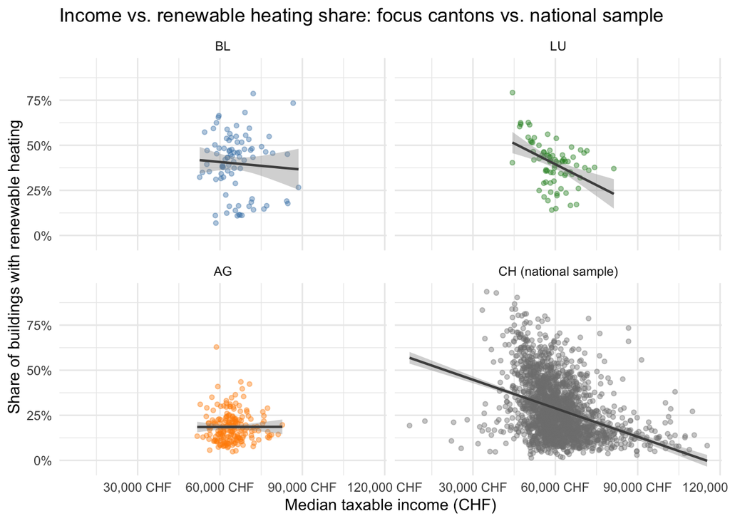

```r
# ── Schritt 3: Scatterplot Income vs. Renewable, facettiert ───────────────────
muni_analysis %>%
  filter(canton %in% selected_cantons) %>%
  bind_rows(
    muni_analysis %>% mutate(canton = "CH (national sample)")
  ) %>%
  mutate(canton = factor(canton,
                         levels = c("BL", "LU", "AG", "CH (national sample)"))) %>%
  ggplot(aes(median_income, share_renewable, colour = canton)) +
  geom_point(alpha = 0.4, size = 1.2) +
  geom_smooth(method = "lm", se = TRUE, linewidth = 0.8, colour = "grey30") +
  facet_wrap(~ canton, nrow = 2) +
  scale_x_continuous(labels = scales::comma_format(suffix = " CHF")) +
  scale_y_continuous(labels = scales::percent_format()) +
  scale_colour_manual(values = c("BL" = "steelblue",
                                 "LU" = "forestgreen",
                                 "AG" = "darkorange",
                                 "CH (national sample)" = "grey50")) +
  labs(
    title = "Income vs. renewable heating share: focus cantons vs. national sample",
    x     = "Median taxable income (CHF)",
    y     = "Share of buildings with renewable heating"
  ) +
  theme_minimal() +
  theme(legend.position = "none")
```

```r
# ── Schritt 4: Subgruppenregressionen ─────────────────────────────────────────
m_bl <- lm(share_renewable ~ median_income + share_lowqual +
             share_efh + share_pre1945 + factor(typology_3) + log_pop,
           data = muni_analysis %>% filter(canton == "BL"))

m_lu <- lm(share_renewable ~ median_income + share_lowqual +
             share_efh + share_pre1945 + factor(typology_3) + log_pop,
           data = muni_analysis %>% filter(canton == "LU"))

m_ag <- lm(share_renewable ~ median_income + share_lowqual +
             share_efh + share_pre1945 + factor(typology_3) + log_pop,
           data = muni_analysis %>% filter(canton == "AG"))

# Vergleichstabelle
modelsummary(
  list("BL (high quality)" = m_bl,
       "LU (medium quality)" = m_lu,
       "AG (low quality)" = m_ag,
       "M3 National" = m3),
  coef_map = c(
    "median_income"       = "Median income (CHF)",
    "share_lowqual"       = "Share low-quality entries",
    "share_efh"           = "Share single-family houses",
    "share_pre1945"       = "Share pre-1945 buildings",
    "factor(typology_3)2" = "Peri-urban (ref: urban)",
    "factor(typology_3)3" = "Rural (ref: urban)",
    "log_pop"             = "Log population"
  ),
  stars = c("*" = 0.05, "**" = 0.01, "***" = 0.001),
  gof_map = c("nobs", "r.squared", "adj.r.squared"),
  fmt = fmt_significant(2),
  notes = "OLS with default standard errors. Canton-level subgroup models
           use M3 specification without cantonal fixed effects."
)
```

|  | BL (high quality) | LU (medium quality) | AG (low quality) | M3 National |
| --- | --- | --- | --- | --- |
| Median income (CHF) | 4.9e-06** | -7.0e-06** | -1.7e-06* | -4.2e-06*** |
|  | (1.5e-06) | (2.1e-06) | (8.5e-07) | (2.9e-07) |
| Share low-quality entries | 0.60* | -0.19 | -0.260*** | -0.105*** |
|  | (0.23) | (0.11) | (0.042) | (0.015) |
| Share single-family houses | -0.011 | 0.047 | 0.031 | 0.128*** |
|  | (0.168) | (0.194) | (0.082) | (0.025) |
| Share pre-1945 buildings | 0.058 | -0.17 | 0.018 | -0.072*** |
|  | (0.129) | (0.22) | (0.057) | (0.019) |
| Peri-urban (ref: urban) | 0.137*** | 0.021 | -0.0085 | 0.0415*** |
|  | (0.031) | (0.038) | (0.0118) | (0.0085) |
| Rural (ref: urban) | 0.154*** | 0.027 | 0.044** | 0.1111*** |
|  | (0.041) | (0.045) | (0.015) | (0.0097) |
| Log population | -0.058*** | -0.04* | -0.045*** | -0.0196*** |
|  | (0.015) | (0.02) | (0.007) | (0.0031) |
| Num.Obs. | 86 | 79 | 195 | 2098 |
| R2 | 0.796 | 0.359 | 0.523 | 0.323 |
| R2 Adj. | 0.778 | 0.296 | 0.505 | 0.321 |

* p < 0.05, ** p < 0.01, *** p < 0.001  
OLS with default standard errors. Canton-level subgroup models use M3 specification without cantonal fixed effects.

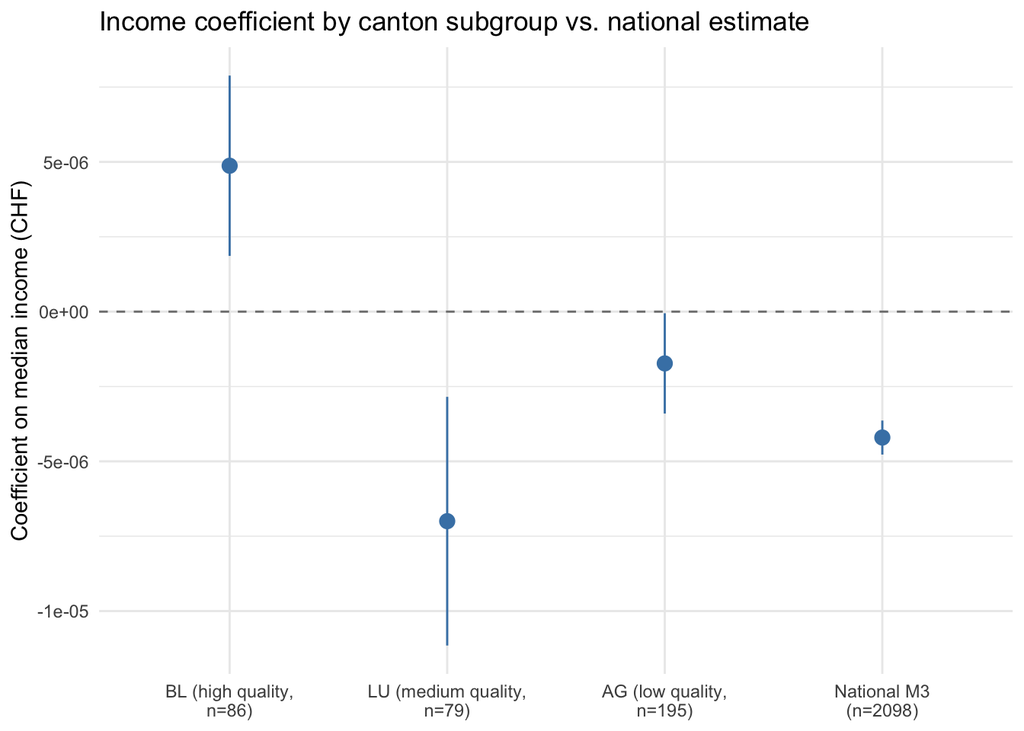

```r
# ── Schritt 5: Koeffizientenplot Income über alle Subgruppen ──────────────────
coef_subgroup <- bind_rows(
  tidy(m_bl, conf.int = TRUE) %>% mutate(model = "BL (high quality,\nn=86)"),
  tidy(m_lu, conf.int = TRUE) %>% mutate(model = "LU (medium quality,\nn=79)"),
  tidy(m_ag, conf.int = TRUE) %>% mutate(model = "AG (low quality,\nn=195)"),
  tidy(m3,   conf.int = TRUE) %>% mutate(model = "National M3\n(n=2098)")
) %>%
  filter(term == "median_income") %>%
  mutate(model = factor(model, levels = c(
    "BL (high quality,\nn=86)",
    "LU (medium quality,\nn=79)",
    "AG (low quality,\nn=195)",
    "National M3\n(n=2098)"
  )))

ggplot(coef_subgroup,
       aes(x = model, y = estimate, ymin = conf.low, ymax = conf.high)) +
  geom_hline(yintercept = 0, linetype = "dashed", colour = "grey50") +
  geom_pointrange(colour = "steelblue", size = 0.6) +
  labs(
    title = "Income coefficient by canton subgroup vs. national estimate",
    x     = NULL,
    y     = "Coefficient on median income (CHF)"
  ) +
  theme_minimal()
```

Figure 12: Income versus renewable heating share for the three focus cantons (Basel-Landschaft, Lucerne, Aargau) compared to the national sample, with per-facet OLS regression lines.

Figure 13: Point estimate and 95% confidence interval of the income coefficient from the M3 specification estimated separately for each focus canton and compared to the national estimate.

The canton-level subgroup analysis yields a striking finding that substantially enriches the interpretation of the national results. The income coefficient varies systematically with data quality across the three cantons, consistent with the hypothesis that measurement error in low-quality cantons attenuates the true income–renewables relationship.

In Basel-Landschaft, the canton with the best documented data quality (share_lowqual = 9.4%), the income coefficient is positive and significant (+4.9e-06, p < 0.01): within BL, higher-income municipalities have a higher renewable heating share, which is the theoretically expected direction. In Aargau, the low-quality comparison canton (share_lowqual = 60.9%), the coefficient is negative and significant (–1.7e-06, p < 0.05), consistent with the national estimate but smaller in magnitude. In Lucerne, the medium-quality canton, the coefficient is negative and larger in magnitude (–7.0e-06, p < 0.01), which suggests that structural canton-specific factors — likely the pronounced urban-rural contrast around the city of Lucerne — dominate the within-canton pattern independently of data quality.

The exceptionally high R² in BL (0.796 vs. 0.323 nationally) confirms that the model fits the high-quality data substantially better, consistent with reduced attenuation bias from outcome measurement error. The positive and significant share_lowqual coefficient in BL (+0.60, p < 0.05) — which is negative in all other specifications — further supports this interpretation: in a canton where data quality is generally high, the remaining low-quality entries likely represent municipalities with high renovation activity where new renewable systems were installed after the Volkszählung 2000 but not formally re-entered into the GWR, producing a spurious positive correlation between low-quality entries and renewable shares. In AG, by contrast, share_lowqual is strongly negative (–0.260, p < 0.001), indicating that in data-poor cantons, low-quality entries genuinely proxy for unrecorded fossil heating systems.

Taken together, the subgroup analysis provides suggestive evidence that the negative national income coefficient is a downward-biased estimate of the true relationship. In the canton with the highest data quality, income is positively associated with renewable adoption — consistent with the theoretical expectation that financial capacity facilitates investment in renewable heating systems. Resolving the ambiguity introduced by LU would require additional canton-level controls or a building-level analysis that directly links heating system records to owner income data.

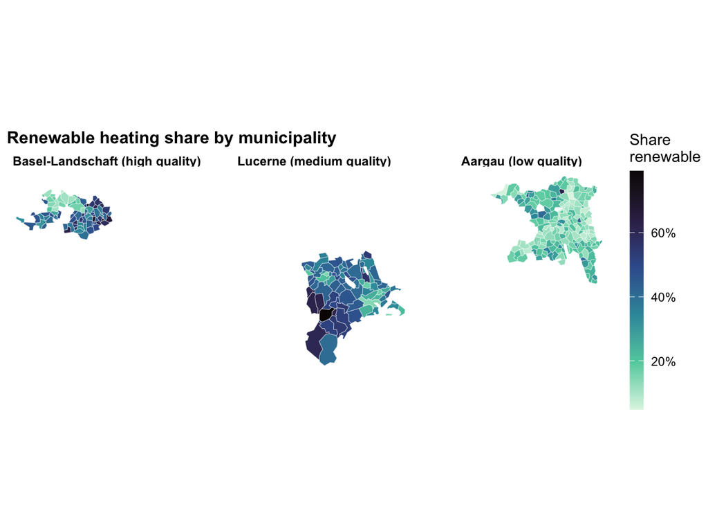

```r
map_data <- map_data %>%
  left_join(muni_analysis %>% select(bfs_id, canton),
            by = c("id" = "bfs_id"))

map_data <- map_data %>%
  rename(canton = canton.x) %>%
  select(-canton.y)

# Kantone filtern
cantons_focus <- c("BL", "LU", "AG")

map_data_cantons <- map_data %>%
  filter(canton %in% cantons_focus) %>%
  mutate(canton_label = case_when(
    canton == "BL" ~ "Basel-Landschaft (high quality)",
    canton == "LU" ~ "Lucerne (medium quality)",
    canton == "AG" ~ "Aargau (low quality)"
  ),
  canton_label = factor(canton_label, levels = c(
    "Basel-Landschaft (high quality)",
    "Lucerne (medium quality)",
    "Aargau (low quality)"
  )))

kantone_focus <- kantone_sf %>%
  filter(id %in% c("BL", "LU", "AG"))  # Spaltenname ggf. anpassen

# Karte 1 — Anteil erneuerbare Heizungen, facettiert nach Kanton
p_canton_renewable <- ggplot() +
  geom_sf(data = map_data_cantons,
          aes(fill = share_renewable),
          colour = "white", linewidth = 0.1) +
  geom_sf(data = kantone_focus,
          fill = NA, colour = "white", linewidth = 0.8) +
  facet_wrap(~ canton_label, nrow = 1) +
  scale_fill_viridis_c(
    option    = "mako",
    direction = -1,
    labels    = scales::percent_format(accuracy = 1),
    na.value  = "grey88",
    name      = "Share\nrenewable"
  ) +
  labs(title = "Renewable heating share by municipality") +
  map_theme +
  theme(strip.text = element_text(size = 9, face = "bold"))

# Karte 2 — Medianeinkommen, facettiert nach Kanton
p_canton_income <- ggplot() +
  geom_sf(data = map_data_cantons,
          aes(fill = median_income),
          colour = "white", linewidth = 0.1) +
  geom_sf(data = kantone_focus,
          fill = NA, colour = "white", linewidth = 0.8) +
  facet_wrap(~ canton_label, nrow = 1) +
  scale_fill_viridis_c(
    option    = "rocket",
    direction = -1,
    labels    = scales::comma_format(suffix = " k", scale = 1/1000),
    na.value  = "grey88",
    name      = "Median\nincome\n(CHF)"
  ) +
  labs(title = "Median taxable income by municipality (ESTV 2022)") +
  map_theme +
  theme(strip.text = element_text(size = 9, face = "bold"))

p_canton_renewable
```

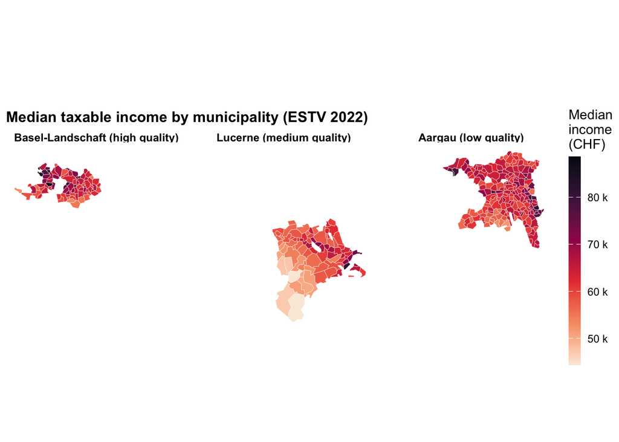

```r
p_canton_income
```

Figure 14: Renewable heating share by municipality for the three focus cantons (Basel-Landschaft, Lucerne, Aargau).

Figure 15: Median taxable income by municipality for the three focus cantons (Basel-Landschaft, Lucerne, Aargau; ESTV 2022).

## Conclusion

This study investigated whether a statistically measurable relationship exists between municipal median income and the share of residential buildings equipped with renewable heating systems across Swiss municipalities, and to what extent this relationship is robust to building stock characteristics and cantonal heterogeneity.

Regarding the first research question, the analysis finds a statistically significant negative relationship between municipal median income and renewable heating adoption across all model specifications. In the fully controlled model with cantonal fixed effects (M4), a 10,000 CHF increase in median municipal income is associated with a 1.8 percentage point reduction in the renewable heating share. This result is robust to the inclusion of district heating in the outcome definition and remains significant at the 0.1% level throughout. The negative direction of the effect runs counter to the intuitive expectation that higher financial capacity facilitates renewable investment, and is best understood as a composition effect: high-income municipalities are structurally urban, characterised by multi-family buildings and gas-based heating infrastructure, while lower-income municipalities are predominantly rural, where wood heating and heat pumps in detached single-family houses have long been the dominant heating form.

Future research could address these limitations by working with building-level panel data that tracks heating system replacements over time, enabling a cleaner identification of the income effect at the point of the investment decision. Exploiting variation in cantonal and communal subsidy programmes as a quasi-experimental instrument would further strengthen causal inference. Such an analysis would require linking GWR building records to owner-level tax data — a data linkage that is technically feasible within the Swiss administrative data infrastructure but requires access beyond publicly available sources.

## Disclosure of the use of AI and GenAI tools

[output not shown]